# Homework 1: US gun murders Solutions

Due September 20, 2019

#### Due: September 20th by 11:59pm

Several of your friends live in Europe and are offered jobs at a US company with many locations all across the country. The job offers are great but news with headlines such as [**America is one of 6 countries that make up more than half of guns deaths worldwide**](https://www.vox.com/2018/8/29/17792776/us-gun-deaths-global) have them worried. Charts like this make them worry even more:

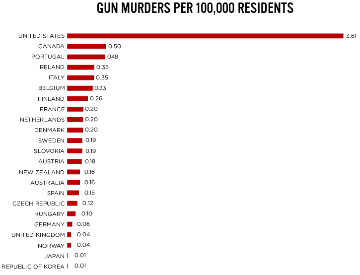

US gun homicides chart

You want to convince your friends that the US is a large and diverse country with 50 very different states as well as the District of Columbia (DC). You want to recommend some states for each friend knowing that some like hiking, while others would like to be close to several large cosmopolitan cities. Use data from the [US murders data set](https://www.rdocumentation.org/packages/dslabs/versions/0.7.1/topics/murders):

```r
library(dslabs)
data(murders)
```

1. What is the state with the most murders? Would you say this is the most dangerous state? Hint: Make a plot showing the relationship between population size and number of murders.

**Solution:**

```r
murders$state[which.max(murders$total)]
```

```
## [1] "California"
```

California is the state with the most murders. However, this does not necessarily make California the most dangerous state. The following plot shows that the number of murders is highly correlated with the population of any given state. California, the state with the highest population, also has the highest total number of murders.

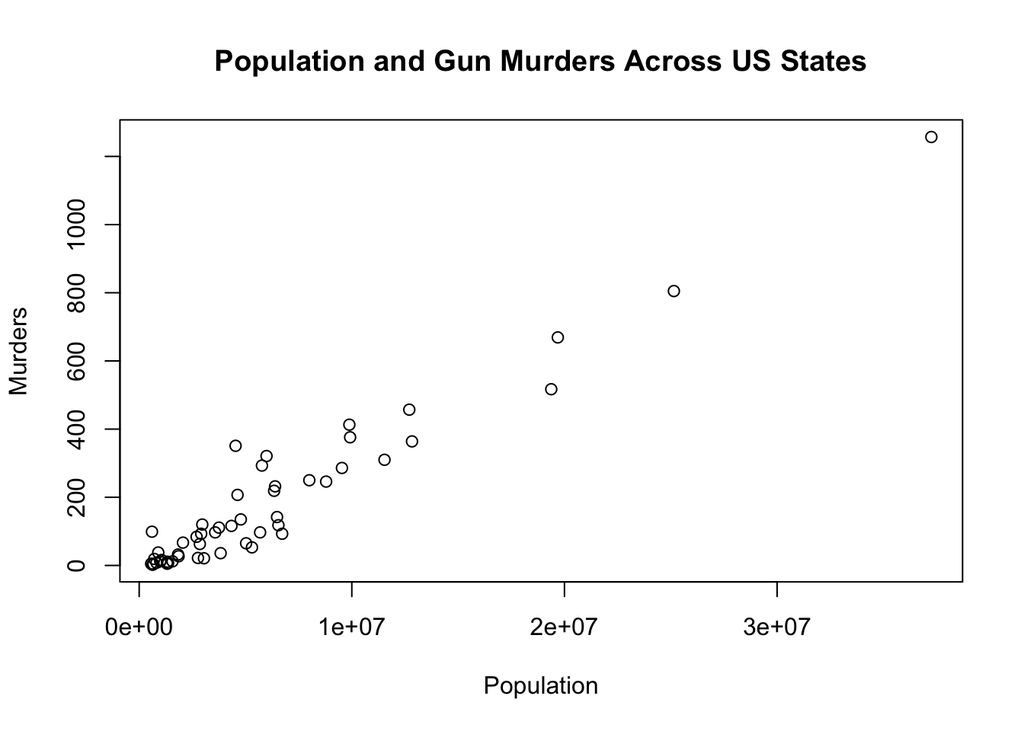

```r
plot(murders$population,
     murders$total,
     xlab = "Population",
     ylab = "Murders",
     main = "Population and Gun Murders Across US States")
```

2. Add a column to the murder data table called `murder_rate` with each state’s murder rate per 100,000 people.

**Solution:**

```r
library(dplyr)
murders <- murders %>% mutate(murder_rate = total / (population / 100000))

## Alternative approach
## murders$murder_rate <- murders$total / murders$population
```

3. Describe the distribution of murder rates across states. How similar are states? How much do murder rates vary by geographical regions?

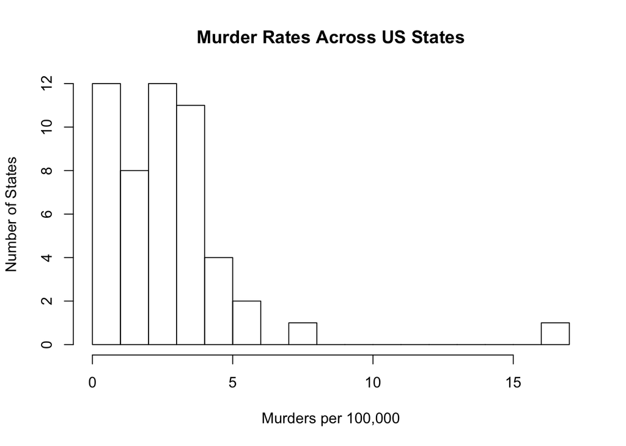

```r
## can use histogram
hist(murders$murder_rate,
     breaks = 15,
     xlab = "Murders per 100,000",
     ylab = "Number of States",
     main = "Murder Rates Across US States")
```

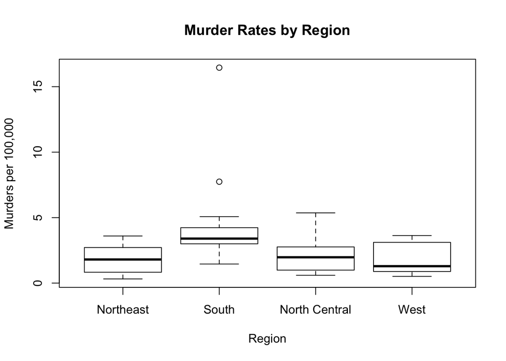

```r
## can use boxplot by region
boxplot(murder_rate ~ region,
        data = murders,
        xlab = "Region",
        ylab = "Murders per 100,000",
        main = "Murder Rates by Region")
```

4. Write a report for your friends reminding them that the US is a large and diverse country with 50 very different states as well as the District of Columbia (DC). Suppose one of your friends loves hiking, one wants to live in a warm climate, and another would like to be close to several large cosmopolitan cities. Recommend a desirable state for each friend. Answers should be a minimum of 1 paragraph and a maximum of 3 paragraphs.

**Solution:** A complete response should include suggestions for each of the three friends based on both their interests (e.g. by considering states good for hiking) and the data analyzed in the previous three problems (e.g. by considering state-level murder rates).